# Lecture 3 - Probability, Random Variables, Estimation

Author: Matthew J. Cossley

Last update: 25 April, 2022

# Learning objectives

- Define **probability** and understand the principles of how to compute it for both discrete and continuous data.
- Define and understand the relationship between **populations**, **samples**, **random variables**, and **probability distributions**.
- Understand the relationship between **sample statistics** and **population parameters**.
- Understand the definition of **Expected Value**.
- Understand how to compute **population mean** and **population variance**.
- Understand the definition of an **estimate** of a population parameter.
- Understand the definition of a **point estimate** and **interval estimate** of population paratmer.
- Understand how to use esample statistics to generate point estimates and interval estimates for **population mean** and **population variance** parameters.
- Understand how to convert a `data.table` from **wide format** to **long format** and vice versa.
- Understand how to use `ggplot` to generate scatter plots, bar plots, box plots, histograms, and violin plots.

# Concepts

## Probability definitions

- An **outcome** is a possible result of an experiment.
- The **sample space** of an experiment is the set of all possible outcomes of that experiment.
- An **event** is a set of outcomes of an experiment.
- An **elementary event** is an event which contains only a single outcome in the sample space.
- Consider the example of flipping a coin twice:

|  | 1st flip | 2nd flip |
| --- | --- | --- |
| outcome 1 | H | H |
| outcome 2 | H | T |
| outcome 3 | T | H |
| outcome 4 | T | T |

- The outcomes of the experiment are the rows of the above table.
- The set of all rows is the sample space $\{(H,H),(H,T),(T,H),(TT)\}$.
- An example event is $\{(H,H), (T,T)\}$.
- Any individual row in the above table corresponds to an elementary event (e.g., $(H,H)$). It is distinct from the outcome $(H,H)$ only in that it is wrapped in a set $\{(H,H)\}$.
- **Probability** is simply the likelihood of an event occurring. If the sample space is **discrete**, and the likelihood of each outcome is equal, then the probability of an event is simply the proportion of outcomes contained by that event relative all possible outcomes.
- A similar definition for probability holds if the space of possible outcomes is **continuous**, but there are a few interesting and not immediately intuitive little kinks that we will need to deal with. For instance, if the sample space is continuous, then the probability of any any single event is actually zero (more on this in a later lecture).

## Rules of probability

- $0 \leq P(e) \leq 1$ for all events $e$.
- The probability of all outcomes in a sample space must sum to $1$.
- The probability that an event $e$ does not occur is given by $P(\neg e)=1-P(e)$.
- For some set of events that share no outcomes, $E=\{e_1,e_2,\ldots,e_n\}$, the probability of all events in $E$ occurring in a single sample is the sum of the probabilities for each occurring individually:

$$P(E) = P(e_1 \cup e_2 \ldots \cup e_n) = P(e_1) + P(e_2) + \ldots + P(e_n)$$

- Note that the notation $P(e_1 \cup e_2)$ indicates the probability of the *union* of $e_1$ and $e_2$ and can be read as the the probability of $e_1$ occurring or event $e_2$ occurring.
- Two events $e_1$ and $e_2$ are **independent** if knowing that one occurs tells you nothing about whether the second will occur. This is given by $P(e_1{\cap}e_2)=P(e_1)P(e_2)$.
- Note that the notation $P(e_1 \cap e_2)$ indicates the probability of the *intersection* of $e_1$ and $e_2$ and can be read as the the probability of $e_1$ occurring and event $e_2$ occurring.

For Example, let $A$, $B$, $C$ share no outcomes and be the possible events of an experiment with the following probabilities of occurrence:

$$P(A) = 0.4 \\
p(B) = 0.3 \\
P(C) = 0.3 \\$$

This is a valid set of probabilities because they obey:

- $0 < P < 1$
- $P(A) + P(B) + P(C) = 1$

Now suppose that we are told:

## Random variables and distributions

A **random variable** is a data generating process. You can think of it like an infinitely deep bucket full of experiment outcomes. Whenever you perform an experiment, you reach into the bucket, and pull out one outcome at random. All possible experiment outcomes contained by the bucket define the **population** under study, and the set of probabilities corresponding to each possible outcome is the **probability distribution**. Probability distributions are in turn defined as functions of one or more **population parameters**. In particular, if $X$ is a random variable with probability distribution $D(\boldsymbol{\theta})$ where the $\boldsymbol{\theta}$’s are population parameters, then we say

$$X \sim D(\theta_1, \ldots, \theta_n)$$

In words, this reads *X is distributed as D with parameters* $\theta_1, \ldots, \theta_n$.

## Sample statistics estimate population parameters

Any outcome you pull out of the bucket is a **sample** from the **random variable**. In general, we use **sample statistics** to **estimate** population parameters. An estimate of a population parameter is our best guess for what a population parameters true value is. For example, we use the sample mean to estimate the population mean. Estimation of population parameters with sample statistics is a key step we will always need to take when performing **inferential statistics**.

**The relationship between sample statistics and population parameters is fundamental and absolutely critical to understand.**

### Population mean for discrete $X$

- Let $X$ be a discrete random variable.
- Let $\boldsymbol{x} = \{x_1, \ldots, x_n\}$ be a sample from $X$.

The central tendency of the sample $\boldsymbol{x}$ is given by the **sample mean** $\bar{\boldsymbol{x}}$:
$$\begin{align}
\bar{\boldsymbol{x}} &= \frac{1}{n} \sum_{i=1}^{n} x_{i}
\end{align}$$

The true central tendency of $X$ is given by the **population mean** which is denoted by $\mu$ and is defined by an operation called the **expected value** of $X$ denoted $\mathbb{E}\big[X\big]$:

$$\begin{align}
\mathbb{E}\big[\boldsymbol{X}\big] &= \mu \\
&= x_1 p(x_1) + x_2 p(x_2) + \ldots + x_n p(x_n) \\
&= \sum_{i}^{n} x_i p(x_i)\\
\end{align}$$

If we do not know the true value of the population mean $\mu$ then we can estimate it using the sample mean $\bar{\boldsymbol{x}}$.
$$\begin{align}
\hat{\mu} &= \bar{\boldsymbol{x}}
\end{align}$$

This is called a **point estimate** of $\mu$, because we are specifying a single number (i.e., a single point) that is our best guess for its true value. Later, we will learn about **interval estimates** of population parameters, which provide a range of best guess (e.g., we might try to say that we are $95\%$ percent sure that the true value of some population parameter is between some lower value and some upper value). We will see how to generate interval estimates in a later lecture. For now, it is sufficient to understand their conceptual relationship to point estimates.

### Population variance for discrete $X$

Similarly, a common measure of the spread of a sample is given by the **sample variance** $\boldsymbol{s}^2$:

$$\begin{align}
\boldsymbol{s}^2 &= \frac{1}{n-1} \sum_{i=1}^{n} (x_i - \bar{\boldsymbol{x}})^2
\end{align}$$

The true variance of $X$ is given by the **population variance** which is denoted by $\sigma^2$ and is defined as follows:
$$\begin{align}
\mathbb{Var}\big[\boldsymbol{X}\big] &= \sigma^2 \\
&= \mathbb{E}\big[(X - \mu)^2\big] \\
&= \sum(x^2 - 2x\mu + \mu^2) p(x) \\
&= \sum x^2 p(x) - \sum 2 x \mu p(x) + \sum \mu^2 p(x) \\
&= \sum x^2 p(x) - 2 \mu \sum x p(x) + \mu^2 \sum p(x) \\
&= \sum x^2 p(x) - 2 \mu^2 + \mu^2 \\
&= \left(\sum_i x_{i}^2 p(x_{i})\right) - \mu^2
\end{align}$$

If we do not know the true value of the population variance $\sigma^2$ then we can estimate it using the sample variance $\bar{\boldsymbol{s}^2}$.
$$\begin{align}
\hat{\sigma^2} &= \boldsymbol{s}^2 \\
\end{align}$$

### Discrete $X$ example

As a concrete example, consider the following discrete probability distribution corresponding to the random variable $X$.

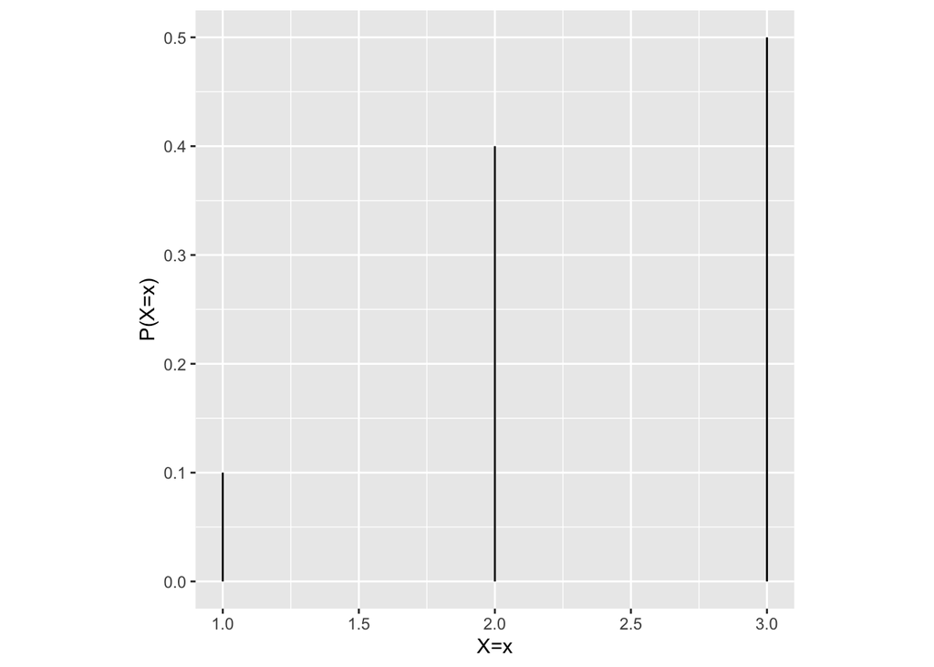

**Note that this is a probability distribution. It defines how likely outcomes from a random variable is. It is not itself a sample from a random variable**

Since we are explicitly given the probability distribution — i.e., we are told exactly what the probability of each event is — so we can calculate the population mean $\mu$ as follows:

$$\begin{align}
\mu &= \mathbb{E}\big[\boldsymbol{X}\big] \\
&= \sum_{i}^{n} x_i p(x_i) \\
&= (1 \times 0.1) + (2.0 \times 0.4) + (3.0 \times 0.5) \\
&= 2.4
\end{align}$$

**Notice here that we have calculated the true value of a population parameter, yet we have not collected a single observation from an experiment. This is only possible because we were given the true probability distribution. When we are given exact probability distributions, then we can calculate population parameters exactly. When we are not given exact probability distributions, then we must estimate population parameters using sample statistics obtained by performing an experiment in which we sample from the random variable under consideration.**

Now suppose that we draw a the following sample of $n=10$ from this distribution:

```
## [1] "x:"
##  [1] 3 2 3 2 3 3 2 2 2 3
## [1] "sample mean:"
## [1] 2.5
```

The sample mean of this sample is $\bar{\boldsymbol{x}} =$ 2.5. Note that our sample mean is not equal to the population mean (it’s just a fluke if it is). In fact, every time we run this experiment, we will likely get a different sample mean. Lets run it 5 more times and check each one.

```
## [1] "x:"
##  [1] 1 2 3 2 3 2 3 3 3 3
## [1] "sample mean:"
## [1] 2.5
## [1] "x:"
##  [1] 1 3 3 2 2 3 3 3 3 2
## [1] "sample mean:"
## [1] 2.5
## [1] "x:"
##  [1] 2 2 3 3 3 3 3 3 2 3
## [1] "sample mean:"
## [1] 2.7
## [1] "x:"
##  [1] 2 3 3 2 3 3 3 2 2 1
## [1] "sample mean:"
## [1] 2.4
## [1] "x:"
##  [1] 2 3 3 3 3 3 1 3 3 3
## [1] "sample mean:"
## [1] 2.7
```

**This indicates that the sample mean is different every time we run the experiment, and therefore, the sample mean is a random variable itself! This idea is very important to how we go about performing statistical inference, and we will treat it more formally in later lectures. For now, make sure you see clearly why and how we know it is a random variable**

### Population mean and variance for continuous $X$

- Let $X$ be a continuous random variable.
- Let $\boldsymbol{x} = \{x_1, \ldots, x_n\}$ be a sample from $X$.
- Sample statistics are computed in exacrtly the same way regardless of whether $X$ is continuous or discrete.
- Population parameters are again computed in terms of the **expected value** operator, but the way this operator works is a bit different depending on whether $X$ is continuous or discrete.
- In particular, if $X$ is continuous, then we will replace discrete sums (i.e., $\sum x$) with continuous integrals (i.e., $\int x dx$).

#### Continuous $X$ mean

$$\begin{align}
\bar{\boldsymbol{x}} &= \frac{1}{n} \sum_{i=1}^{n} x_{i}
\\
\mathbb{E}\big[\boldsymbol{X}\big] &= \mu \\
&= \int x f(x) dx \\
\\
\hat{\mu} &= \bar{\boldsymbol{x}}
\end{align}$$

#### Continuous $X$ variance

$$\begin{align}
\boldsymbol{s}^2 &= \frac{1}{n-1} \sum_{i=1}^{n} (x_i - \bar{\boldsymbol{x}})^2
\\
\mathbb{Var}\big[\boldsymbol{X}\big] &= \sigma^2 \\
&= \mathbb{E}\big[(X - \mu)^2\big] \\
&= \int(x^2 - 2x\mu + \mu^2) f(x) dx \\
&= \int x^2 f(x) dx - \int 2 x \mu f(x) dx + \int \mu^2 f(x) dx \\
&= \int x^2 f(x) dx - 2 \mu \int x f(x) dx + \mu^2 \int f(x) dx \\
&= \int x^2 f(x) dx - 2 \mu^2 + \mu^2 \\
&= \left(\int x^2 fx \right) - \mu^2
\\
\hat{\sigma^2} &= \boldsymbol{s}^2
\\
\end{align}$$

### Continuous $X$ example

As a concrete example, consider the following continuous probability distribution corresponding to the random variable $X$.

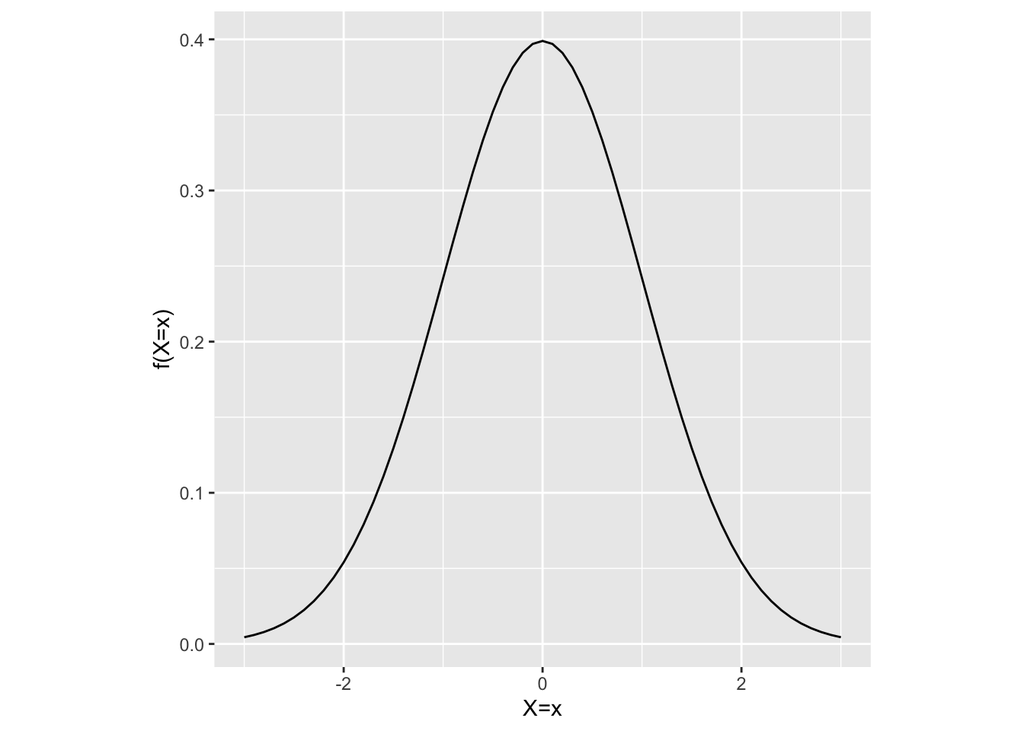

**Notice that the y-axis is not labelled with $P(X=x)$. This is because when $X$ is continuous $P(X=x)=0$ for all $x$. The $f(x)$ label refers to probability density. We will discuss this more formally in a later lecture.**

As for our discrete $X$ example, we are explicitly given the probability distribution — i.e., we are told exactly what the probability *density* of each event is — so we can calculate the population mean $\mu$ as follows:

$$\begin{align}
\mu &= E(\boldsymbol{X}) \\
&= \int x p(x) dx \\
&= 0 \\
\end{align}$$

**Note that you will not be expacted to evaluate difficulr integrals in this unit. You will, however, need to understand the trick I used to evaluate this integral. The trick is see that the distribution is symmetric, and so the expected value is the peak value.**

Now suppose that we draw a the following sample of $n=10$ from this distribution:

```
## [1] "x:"
##  [1] -0.230361233 -0.009745505  0.009771315  0.953166470  1.078100675
##  [6] -0.703407020  0.852616964  2.440848259  1.346394015  0.007763907
## [1] "sample mean:"
## [1] 0.5745148
```

The sample mean of this sample is $\bar{\boldsymbol{x}} =$ 0.5745148. As for our discrete $X$ exmaple, we see that our sample mean is not equal to the population mean. Lets run it 5 more times to demonstrate again that the sample mean is indeed a ranomd variable.

```
## [1] "x:"
##  [1]  0.95788294  1.61543982  0.46400299 -0.05705782 -0.38668254  0.01658400
##  [7]  0.63326515  0.69398629 -0.66859118 -0.98325470
## [1] "sample mean:"
## [1] 0.2285575
## [1] "x:"
##  [1] -0.6394258 -1.3629453 -0.6707844  1.1507990  1.6134491 -0.1176446
##  [7] -1.0885994 -1.4745112 -0.9462879  0.8014487
## [1] "sample mean:"
## [1] -0.2734502
## [1] "x:"
##  [1] -1.83990383  0.54980579 -0.17324295 -0.04654495 -1.42872225  1.00318562
##  [7]  0.69043196  0.40078525 -1.44915986 -1.08813314
## [1] "sample mean:"
## [1] -0.3381498
## [1] "x:"
##  [1]  1.1114416 -0.1959920 -0.7336813  0.4412400 -1.3947992 -0.7630724
##  [7]  0.7283803 -1.4668280 -1.2057941 -0.7576869
## [1] "sample mean:"
## [1] -0.4236792
## [1] "x:"
##  [1] -0.6867198 -1.3598889  0.9696254  0.1790202  2.0566161  1.4209782
##  [7] -0.7106119  1.8729167 -1.1839005 -0.4278004
## [1] "sample mean:"
## [1] 0.2130235
```

# Practice with `R`

## wide to long format `data.table`

- Suppose you perform an experiment in which you collect data from 3 participants, and each participant gives you 5 observations.
- If this data were represented in *wide* format, then data from each participant would be in separate columns.
- If this data were represented in *long* format, then data from every participant would be in the same column. A separate column would *indicate* what subject a given row corresponded to.
- To convert from wide to long format use the `melt()` function from `data.table`.

```r
# define example data
x1 <- runif(5)
x2 <- runif(5)
x3 <- runif(5)

# create a wide format data.table
d_wide <- data.table(x1, x2, x3)

# convert to a long format data.table
d_long <- melt(d_wide, measure.vars=c('x1', 'x2', 'x3'))

d_wide
##            x1         x2           x3
## 1: 0.24259694 0.80826396 0.0889994509
## 2: 0.74970295 0.03965424 0.6118691501
## 3: 0.96904008 0.81783674 0.8868297925
## 4: 0.07693136 0.84843615 0.0008990094
## 5: 0.56198526 0.47719945 0.4121744505
d_long
##     variable        value
##  1:       x1 0.2425969350
##  2:       x1 0.7497029465
##  3:       x1 0.9690400790
##  4:       x1 0.0769313627
##  5:       x1 0.5619852624
##  6:       x2 0.8082639640
##  7:       x2 0.0396542407
##  8:       x2 0.8178367368
##  9:       x2 0.8484361516
## 10:       x2 0.4771994527
## 11:       x3 0.0889994509
## 12:       x3 0.6118691501
## 13:       x3 0.8868297925
## 14:       x3 0.0008990094
## 15:       x3 0.4121744505
```

## Data visualisation using `ggplot`

Data visualisation is a core component of modern descriptive statistics and it is essential that we become proficient at collecting data, assembling it into csv-style formats, piping it into `R`, and inspecting it using plots.

There are numerous methods to generate plots using `R`, but in this unit, we will focus exclusively on first representing our data as a `data.table` and then using `ggplot` to make plots.

Note that many of the visualisations we will demonstrate below look best when we have lots of data, so lets make a bigger toy example now.

```r
# define example data with more observations
x1 <- runif(100)
x2 <- runif(100)
x3 <- runif(100)

# create a wide format data.table
d_wide <- data.table(x1, x2, x3)

# convert to a long format data.table
d_long <- melt(d_wide, measure.vars=c('x1', 'x2', 'x3'))
```

### `geom_point`

Perhaps the most straightforward approach to visualising data is simply to plot points for each observation in your sample.

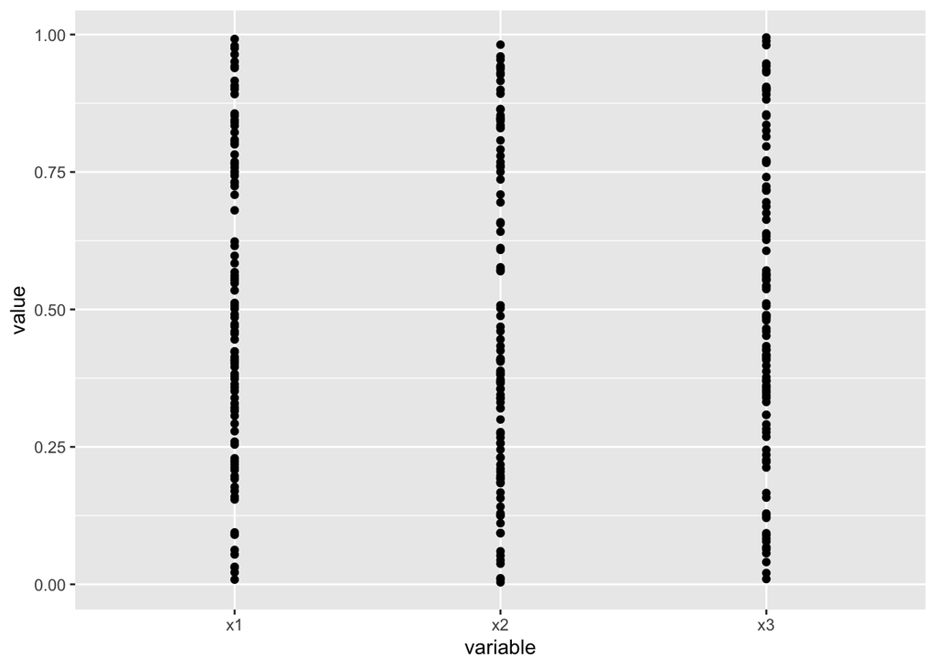

```r
ggplot(data=d_long, aes(x=variable, y=value)) +
  geom_point()
```

### `geom_boxplot`

Box plots give a summary of how your data is distributed by visually marking out the median value as well as the 25th to the 75th percentile. The idea is to concisely illustrate where the majority of the data fall.

Whiskers will typically extend from the ends of the box to indicate the more extreme end of your data, and very extreme data points will often be plotted individually. This aspect of box plots doesn’t have as strong a convention as the rest, so it’s important to read the documentation to be sure you are plotting what you think you are plotting.

I often find that it can be quite nice to use both `geom_point` and `geom_box` in conjunction as follows.

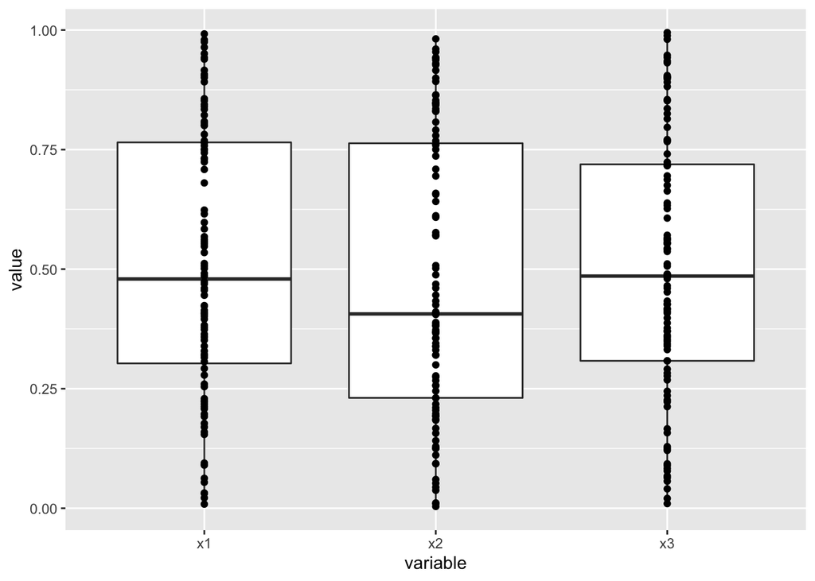

```r
ggplot(data=d_long, aes(x=variable, y=value)) +
  geom_boxplot() +
  geom_point()
```

### `geom_violin`

Violin plots are similar to box plots, except rather than represent your data in terms of percentiles, it attempts to give you a continuous estimate of how much our your data fall along the range of possible values. As with box plots, I often like to overlay individual points.

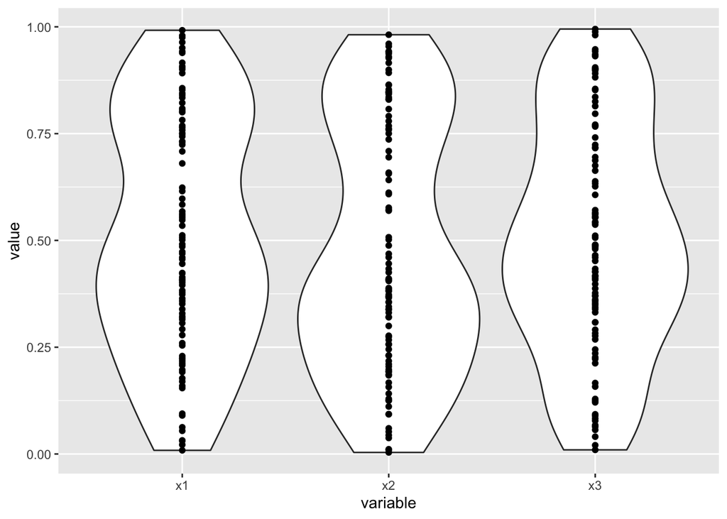

```r
ggplot(data=d_long, aes(x=variable, y=value)) +
  geom_violin() +
  geom_point()
```

### `geom_hist`

A histogram attempts to illustrate how data is distributed by grouping data points into a set number of bins, and plotting a bar with height equal to the number of points in each bin.

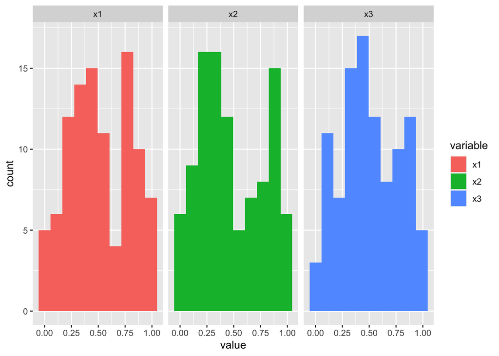

```r
ggplot(data=d_long, aes(x=value, fill=variable)) +
  geom_histogram(bins = 10) +
  facet_wrap(~variable)
```

### `geom_bar`

Bar plots are among the most common plots you will encounter as you navigate pretty much any scientific field. They throw away all information about how your data is distributed, and instead report only on the average values (unless error bars are included).

There are many ways to use `ggplot` and `geom_bar` to make a bar plot. A good way to start is to first create a `data.table` that contains only the average values that you want to be represented by the bar heights:

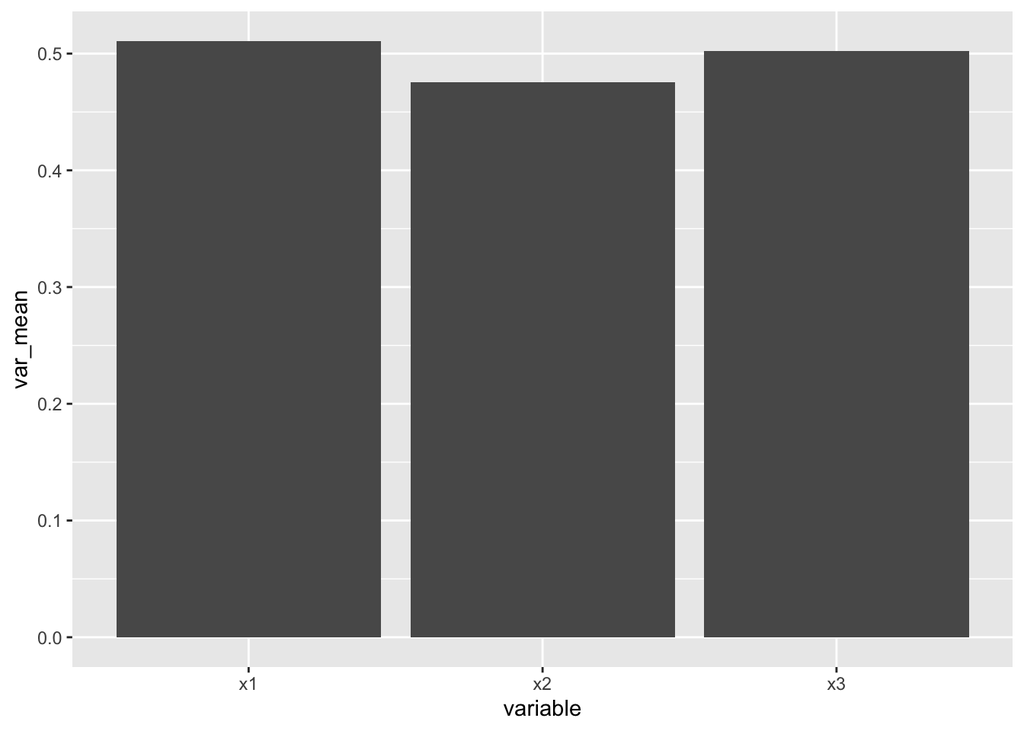

```r
d_mean = d_long[, .(var_mean = mean(value)), .(variable)]
ggplot(data=d_mean, aes(x=variable, y=var_mean)) +
  geom_bar(stat='identity')
```

### `geom_line`

Of course, in certain circumstance, we might want to make a simple line plot. This is also easy to achieve with `ggplot`, but to demonstrate its use, we will need a different example data set.

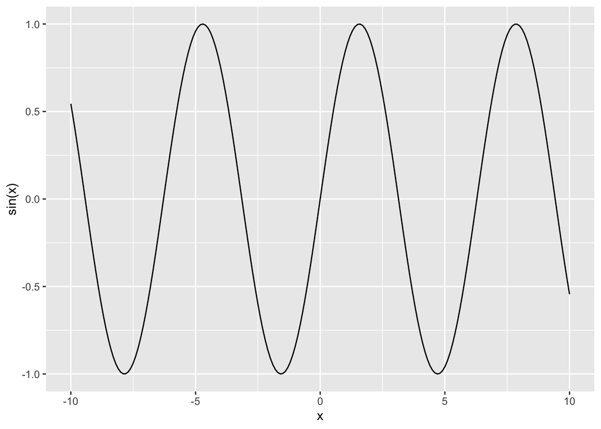

```r
x <- seq(-10, 10, 0.1)
y <- sin(x)
d <- data.table(x, y)

ggplot(data=d, aes(x=x, y=y))+
  geom_line() +
  ylab('sin(x)')
```